# Exercise 1 (20 minutes)

When you're done, assist some of the others ...

1. Start a new R-Script and copy the lines of R code from my slides that generate 'Dat'. Alter the code such that former Danish colonies are identified. Unfortunately, we only have two countries in the World Bank data that can be somewhat considered as former Danish colonies according to [Wikipedia](https://en.wikipedia.org/wiki/Danish_overseas_colonies): Iceland and Estonia. Check Wikipedia to see when they became independent from Denmark.

```r
pacman::p_load(
  tidyverse, # Data manipulation,
  ggplot2, # beautiful figures,
  vdemdata, # download democracy datasets used in the scholarly literature.
  wbstats, # download data from Worldbank. Tremendous source of global socio-economic data.
  estimatr, # OLS with robust SE,
  modelsummary) # regression tables with nice layout,

# 1. The world Bank data
Dat <- wb_data("SI.POV.DDAY", # Download poverty data: <2.15$ per day,
               start_date = 2000, end_date = 2025) %>%
  rename(poverty = SI.POV.DDAY) %>% # rename poverty variable,
  select(country, date, poverty) %>% # Keep only 3 variables
  drop_na(poverty) %>% # Drop cases with missing data,
  group_by(country) %>% # Group by country,
  filter(date == max(date)) %>% # Keep the most recent data per country.
  mutate(date = as.numeric(date)) %>% ungroup()

# 2. Colonizer data
Dat <- Dat %>%
  mutate(
    colonizer = case_when(
      str_detect(country, "Algeria|Benin|Burkina Faso|Cambodia|Central African Republic|Chad") |
        str_detect(country, "Djibouti|Gabon|Guinea|Laos|Haiti|Lebanon|Madagascar|Mali|Congo, Rep.|Cote D'Ivoire") |
        str_detect(country, "Mauritania|Niger|Senegal|Syria|Togo|Tunisia|Viet Nam") ~ "France", # France
      str_detect(country, "Bahrain|Bangladesh|Botswana|Cyprus|Egypt|Fiji") |
        str_detect(country, "Gambia|Ghana|Guyana|India|Iraq|Jamaica|Jordan|Kenya|Kuwait") |
        str_detect(country, "Lesotho|Malawi|Malaysia|Mauritius|Myanmar|Nigeria|Oman") |
        str_detect(country, "Pakistan|Qatar|Sierra Leone|Singapore") |
        str_detect(country, "Sri Lanka|Sudan|Swaziland|Tanzania|Trinidad/Tobago|Uganda") |
        str_detect(country, "United Arab Emirates|Yemen|Zambia|Zimbabwe") ~ "Britain", # Britain
      str_detect(country, "Burundi|Congo, Dem. Rep.|Rwanda") ~ "Belgium", # Belgium
      str_detect(country, "Iceland|Estonia") ~ "Denmark")) # Denmark

# 3. Independence from colonialism data
Dat <- Dat %>%
  mutate(
    years_indep = case_when(
      is.na(colonizer) ~ as.numeric(NA),
      country == "Estonia" ~ date - 1645,
      country == "United States" ~ date - 1783, country == "Haiti" ~ date - 1804,
      country == "Paraguay" ~ date - 1811, country == "Chile" ~ date - 1818,
      str_detect(country, "Argentina|Bolivia|Colombia") ~ date - 1819,
      str_detect(country, "Costa Rica|Dominican Republic|Mexico|Nicaragua|Panama|El Salvador|Guatemala|Honduras|Venezuela") ~ date - 1821,
      str_detect(country, "Brazil|Ecuador") ~ date - 1822,
      country == "Peru" ~ date - 1824, country == "Uruguay" ~ date - 1828,
      country == "Cuba" ~ date - 1899, country == "Australia" ~ date - 1901,
      country == "New Zealand" ~ date - 1907, country == "South Africa" ~ date - 1910,
      country == "Egypt" ~ date - 1922, country == "Iraq" ~ date - 1932,
      str_detect(country, "Iceland") ~ date - 1944,
      str_detect(country, "Korea|Taiwan|Vietnam") ~ date - 1945,
      str_detect(country, "Lebanon|Philippines|Syria") ~ date - 1946,
      str_detect(country, "Bangladesh|Pakistan|India|Liberia") ~ date - 1947,
      str_detect(country, "Myanmar|Israel|Jordan|Sri Lanka") ~ date - 1948,
      country == "Indonesia" ~ date - 1949, country == "Libya" ~ date - 1951,
      str_detect(country, "Cambodia|Loas") ~ date - 1954,
      str_detect(country, "Morocco|Sudan|Tunisia") ~ date - 1956,
      str_detect(country, "Malaysia|Ghana") ~ date - 1957,
      country == "Guinea" ~ date - 1958, country == "Singapore" ~ date - 1959,
      str_detect(country, "Benin|Burkina Faso|Central African Republic|Chad|Congo, Dem. Rep.|Congo, Rep.|Code D'Ivoire|Mali|Mauritania|Niger|Nigeria|Senegal|Gabon|Somalia|Togo") ~ date - 1960,
      str_detect(country, "Kuwait|Sierra Leone|Tanzania") ~ date - 1961,
      str_detect(country, "Algeria|Burundi|Rwanda|Jamaica|Trinidad/ Tobago|Uganda") ~ date - 1962,
      country == "Kenya" ~ date - 1963,
      str_detect(country, "Malawi|Zambia") ~ date - 1964,
      str_detect(country, "Gambia|Zimbabwe") ~ date - 1965,
      str_detect(country, "Botswana|Lesotho|Guyana") ~ date - 1966,
      str_detect(country, "Canada|Yemen") ~ date - 1967,
      str_detect(country, "Mauritius|Swaziland") ~ date - 1968,
      country == "Fiji" ~ date - 1970,
      str_detect(country, "Bahrain|Oman|Qatar|United Arab Emirates") ~ date - 1971,
      country == "Guinea-Bissau" ~ date - 1974,
      str_detect(country, "Angola|Mozambigue|Papua New Guinea") ~ date - 1975,
      country == "Djibouti" ~ date - 1977,
      country == "Namibia" ~ date - 1990))
```

2. How does the Danish colonial legacy compare to that of other countries in terms of extreme poverty? Can this be intepreted as a causal effect of Danish colonial rule and legacy?

```r
ols2 <- lm_robust(poverty ~  colonizer, data = Dat)
modelsummary(list("Poverty" = ols2), stars = TRUE,
             coef_rename = c("colonizerDenmark" = "Denmark",
                             "colonizerFrance" = "France", "colonizerBritain" = "Britain",
                             "colonizerPortugal" = "Portugal", "colonizerSpain" = "Spain"),
             gof_map = c("nobs", "r.squared"))
```

|  | Poverty |
| --- | --- |
| (Intercept) | 74.433*** |
|  | (6.208) |
| Britain | -50.609*** |
|  | (7.843) |
| Denmark | -74.033*** |
|  | (6.208) |
| France | -45.183*** |
|  | (7.851) |
| Num.Obs. | 58 |
| R2 | 0.212 |

+ p < 0.1, * p < 0.05, ** p < 0.01, *** p < 0.001

3. Use the V-Dem House data.

```r
(Dat_vdem <- vdem %>% # The data are part of the package we loaded earlier
   as_tibble() %>% # turn into a tiblle
   select(country_name, country_text_id, year, v2xcl_rol) %>%
   rename(equal_liberty = v2xcl_rol, # rename liberty variable
          date = year,
          country = country_name)) #rename country variable
# # A tibble: 27,913 × 4
#    country country_text_id  date equal_liberty
#    <chr>   <chr>           <dbl>         <dbl>
#  1 Mexico  MEX              1789         0.204
#  2 Mexico  MEX              1790         0.204
#  3 Mexico  MEX              1791         0.204
#  4 Mexico  MEX              1792         0.204
#  5 Mexico  MEX              1793         0.204
#  6 Mexico  MEX              1794         0.204
#  7 Mexico  MEX              1795         0.204
#  8 Mexico  MEX              1796         0.204
#  9 Mexico  MEX              1797         0.204
# 10 Mexico  MEX              1798         0.204
# # ℹ 27,903 more rows
# 2. Join Dat and Freedom House data
Dat <- inner_join(Dat, Dat_vdem, by = c("country", "date"))
```

4. Make a scatter plot with citizenship rights as outcome on the Y-axis and the years since independence as predictor on the X-axis. Make sure to add a regression line with 95% confidence interval to it.

[figure not shown]

```r
ggplot(data = Dat, aes(y = equal_liberty, x = years_indep)) +
  geom_smooth(method = "lm") +
  geom_text(aes(label = country)) +
  labs(y = "Freedom House index of citizenship rights",
       x = "Years since idependence from colonialism") +
  theme_minimal() +
  guides(color = "none")
```

5. Run an OLS regression with citizenship rights as outcome and the years since independence as predictor. Is the association statistically significant?

```r
ols <- lm_robust(equal_liberty ~  years_indep, data = Dat)
modelsummary(list("Citiz. Rights" = ols), stars = TRUE,
             gof_map = c("nobs", "r.squared"))
```

|  | Citiz. Rights |
| --- | --- |
| (Intercept) | 0.591*** |
|  | (0.065) |
| years_indep | 0.001 |
|  | (0.001) |
| Num.Obs. | 47 |
| R2 | 0.020 |

+ p < 0.1, * p < 0.05, ** p < 0.01, *** p < 0.001

6. Re-run the model using `lm()` and check whether Estonia is an outlier and whether the linearity assumption is strongly violated.

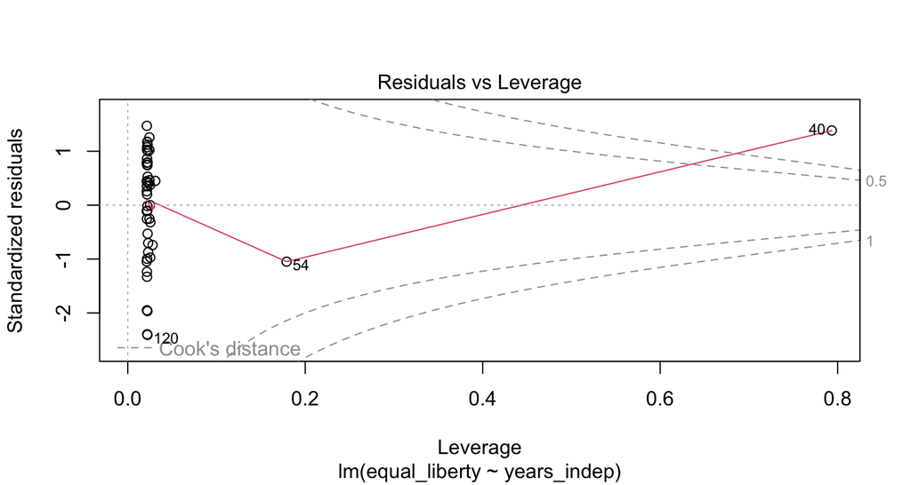

```r
ols <- lm(equal_liberty ~  years_indep, data = Dat)
plot(ols, which = 5) # Outlier
```

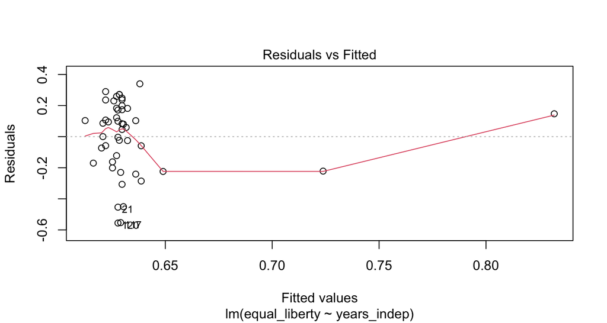

```r
plot(ols, which = 1) #Linearity
```